# How a Markow process may help to model natural rate of unemployment?

Yunbin Peng

March 20, 2018

**An introduction of Markov process by Scott Page from University of Michigan**  
https://www.youtube.com/watch?v=ardJgF1EF4k  
The simulation model is written in R, a popular free programming language if you want to work with data.

```r
library(ggplot2)
markov = function(E0, U0, EP, UP, n) {
  # vector to store result
  E = numeric(n)
  U = numeric(n)

  # initial distribution
  E[1] = E0
  U[1] = U0
  pop = E0+U0

  # initial distribution of individual
  employment = c(rep(T, E[1]), rep(F, U[1]))

  for (i in 2:n) {
    # transition probability
    probabilities = runif(E0+U0)

    # current state
    employment = c(rep(T, E[i-1]), rep(F, U[i-1]))

    # transition
    employment = ifelse(
      (employment == FALSE & probabilities < UP)|(employment == TRUE & probabilities < EP),
      !employment, employment)
    # count after transition
    E[i] = sum(employment)
    U[i] = pop - E[i]
  }
  t = 1:n


  employ = data.frame(time = t, number = E, state = "Employed")
  unemploy = data.frame(time = t, number = U, state = "Unemployed")
  x = rbind(employ, unemploy)

  plot = ggplot(data = x) +
      geom_line(aes(x = time, y = number, color = state))+
      labs(x="number of simulation periods", y = "population")
  return(plot)
}
```

Start with 500 employed and 500 unemployed people.  
Probability for losing job is 5% for employed people (aka 95% chance of remaining employed).  
probability for unemployed people to gain job is 30%.  
The model predicts at the equilibrium around 15% of people are unemployed. aka the natural rate of unemployment is 15% predicted the particular combination of probabilities.

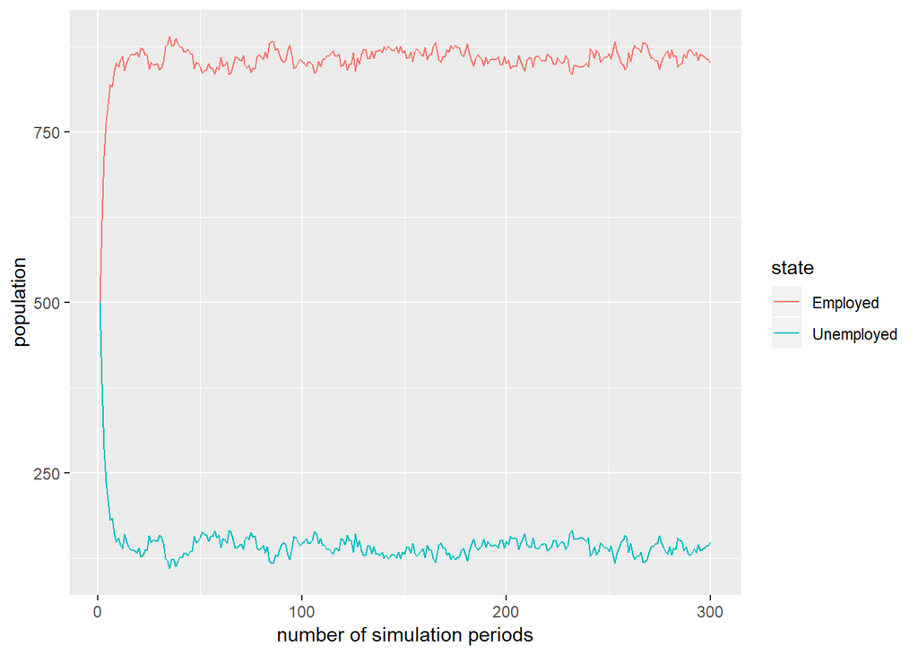

```r
# 1st argument is initial number of employed people
# 2nd argument is initial number of unemployed people
# 3rd argument is probability of employmed people to become unemployed
# 4th argument is probability of unemployed people to becomes employed
# 5th argument is number of periods you want the simulation to run
markov(500, 500, 0.05, 0.3, 300)
```

Start with 900 employed and 100 unemployed people.  
Probability for losing job is 5% for employed people (aka 95% chance of remaining employed).  
probability for unemployed people to gain job is 30%.  
You may observe the probability of staying in the particular employment group and leaving it is the same as before.  
**Even with a different inital population, the equilibrium in the end is still similar**

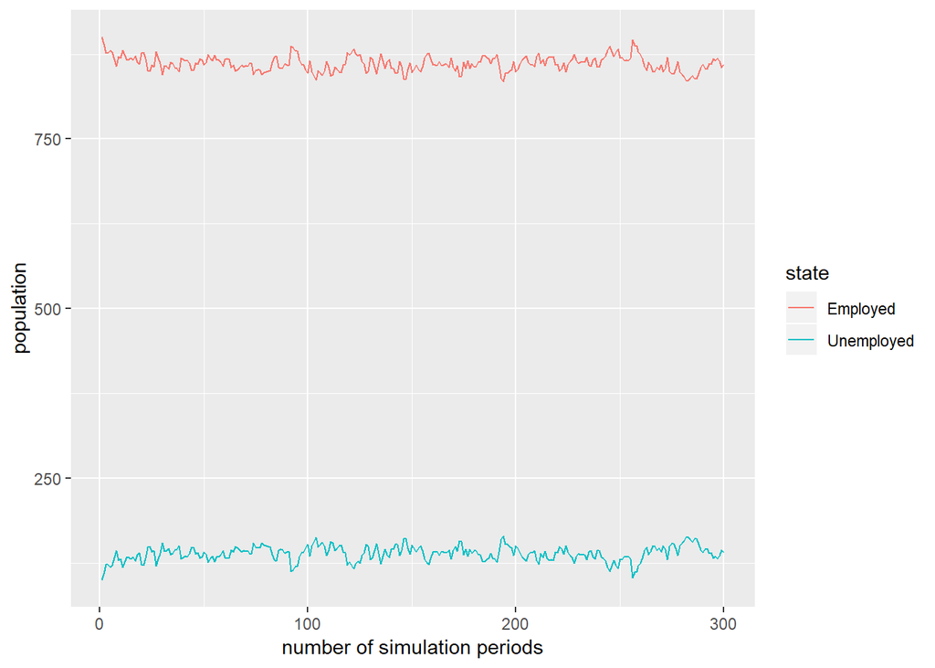

```r
markov(900, 100, 0.05, 0.3, 300)
```

Even if we start with everyone unemployed at the beginning, with the probability stays the same, it will bring everything back to the equilibrium where 15% unemployed.

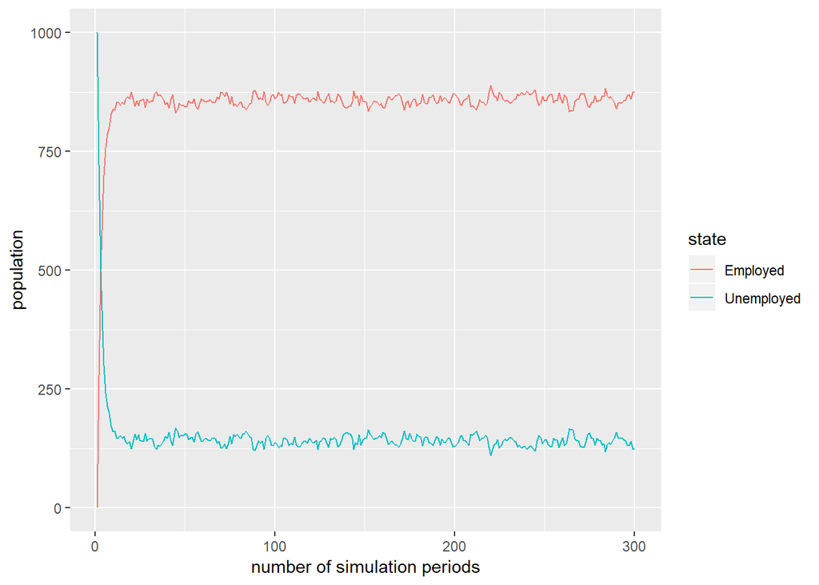

```r
markov(0, 1000, 0.05, 0.3, 300)
```

## How transition probability affects equilibrium?

We see above that if Probability  
P(employed people to becomes unemployed) = 0.05  
P(unemployed people to becomes employed) = 0.3  
Then at the equilibrium 85% employed and 15% unemployed.  
What if now we increase the probability for employed people to become unemployed to 0.1?  
We can see at the equilibrium there is fewer employed people (75%) and more unemployed people (25%).

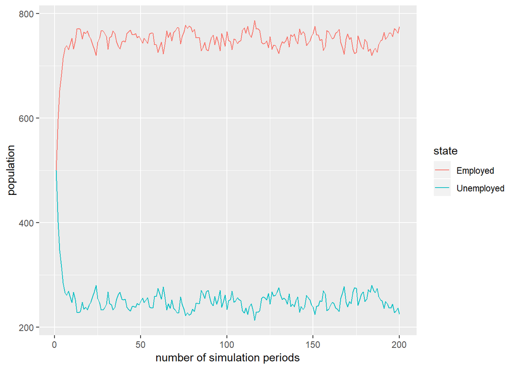

```r
markov(500, 500, 0.1, 0.3, 200)
```

What if we keep the probability of losing job at 0.05, but makes it harder for unemployed people to gain job?  
Then at equilibrium there will be higher unemployment rate 35%.

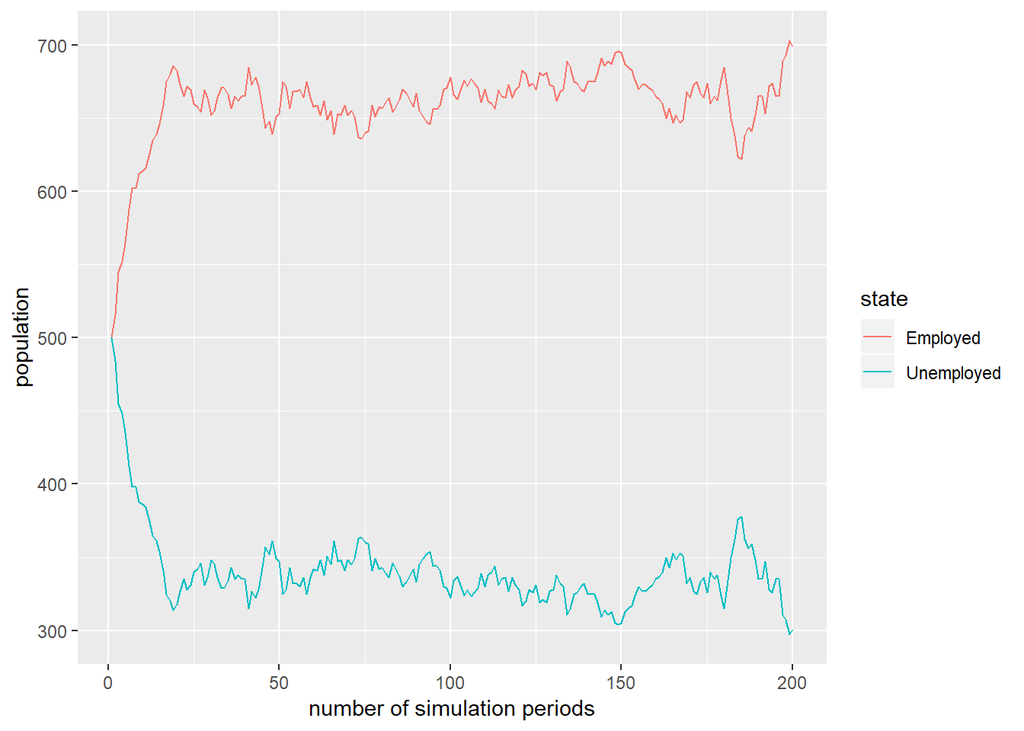

```r
markov(500, 500, 0.05, 0.1, 200)
```